```r
library(ISLR)
library(caret)
library(dplyr)
library(FNN)
library(gmodels)
```

```r
# Import data set
setwd("C:/Users/krish/OneDrive/Desktop/R_MLCODES/rmullapu_64060")

Bank <- read.csv("UniversalBank.csv")
```

A summary of the data set will be displayed to review the data set.

```r
# Provides summary of the data set
summary(Bank)
```

```
##        ID            Age          Experience       Income          ZIP.Code
##  Min.   :   1   Min.   :23.00   Min.   :-3.0   Min.   :  8.00   Min.   : 9307
##  1st Qu.:1251   1st Qu.:35.00   1st Qu.:10.0   1st Qu.: 39.00   1st Qu.:91911
##  Median :2500   Median :45.00   Median :20.0   Median : 64.00   Median :93437
##  Mean   :2500   Mean   :45.34   Mean   :20.1   Mean   : 73.77   Mean   :93153
##  3rd Qu.:3750   3rd Qu.:55.00   3rd Qu.:30.0   3rd Qu.: 98.00   3rd Qu.:94608
##  Max.   :5000   Max.   :67.00   Max.   :43.0   Max.   :224.00   Max.   :96651
##      Family          CCAvg          Education        Mortgage
##  Min.   :1.000   Min.   : 0.000   Min.   :1.000   Min.   :  0.0
##  1st Qu.:1.000   1st Qu.: 0.700   1st Qu.:1.000   1st Qu.:  0.0
##  Median :2.000   Median : 1.500   Median :2.000   Median :  0.0
##  Mean   :2.396   Mean   : 1.938   Mean   :1.881   Mean   : 56.5
##  3rd Qu.:3.000   3rd Qu.: 2.500   3rd Qu.:3.000   3rd Qu.:101.0
##  Max.   :4.000   Max.   :10.000   Max.   :3.000   Max.   :635.0
##  Personal.Loan   Securities.Account   CD.Account         Online
##  Min.   :0.000   Min.   :0.0000     Min.   :0.0000   Min.   :0.0000
##  1st Qu.:0.000   1st Qu.:0.0000     1st Qu.:0.0000   1st Qu.:0.0000
##  Median :0.000   Median :0.0000     Median :0.0000   Median :1.0000
##  Mean   :0.096   Mean   :0.1044     Mean   :0.0604   Mean   :0.5968
##  3rd Qu.:0.000   3rd Qu.:0.0000     3rd Qu.:0.0000   3rd Qu.:1.0000
##  Max.   :1.000   Max.   :1.0000     Max.   :1.0000   Max.   :1.0000
##    CreditCard
##  Min.   :0.000
##  1st Qu.:0.000
##  Median :0.000
##  Mean   :0.294
##  3rd Qu.:1.000
##  Max.   :1.000
```

We need to remove the “ID” and “ZIP.Code” variables from the data set, as stated in problem statement.

```r
# Create a new data set with "ID" and "ZIP.Code" variables removed

Bank_1 <- Bank[ ,-c(1,5)]

# Review the structure of the data set
summary(Bank_1)
```

```
##       Age          Experience       Income           Family
##  Min.   :23.00   Min.   :-3.0   Min.   :  8.00   Min.   :1.000
##  1st Qu.:35.00   1st Qu.:10.0   1st Qu.: 39.00   1st Qu.:1.000
##  Median :45.00   Median :20.0   Median : 64.00   Median :2.000
##  Mean   :45.34   Mean   :20.1   Mean   : 73.77   Mean   :2.396
##  3rd Qu.:55.00   3rd Qu.:30.0   3rd Qu.: 98.00   3rd Qu.:3.000
##  Max.   :67.00   Max.   :43.0   Max.   :224.00   Max.   :4.000
##      CCAvg          Education        Mortgage     Personal.Loan
##  Min.   : 0.000   Min.   :1.000   Min.   :  0.0   Min.   :0.000
##  1st Qu.: 0.700   1st Qu.:1.000   1st Qu.:  0.0   1st Qu.:0.000
##  Median : 1.500   Median :2.000   Median :  0.0   Median :0.000
##  Mean   : 1.938   Mean   :1.881   Mean   : 56.5   Mean   :0.096
##  3rd Qu.: 2.500   3rd Qu.:3.000   3rd Qu.:101.0   3rd Qu.:0.000
##  Max.   :10.000   Max.   :3.000   Max.   :635.0   Max.   :1.000
##  Securities.Account   CD.Account         Online         CreditCard
##  Min.   :0.0000     Min.   :0.0000   Min.   :0.0000   Min.   :0.000
##  1st Qu.:0.0000     1st Qu.:0.0000   1st Qu.:0.0000   1st Qu.:0.000
##  Median :0.0000     Median :0.0000   Median :1.0000   Median :0.000
##  Mean   :0.1044     Mean   :0.0604   Mean   :0.5968   Mean   :0.294
##  3rd Qu.:0.0000     3rd Qu.:0.0000   3rd Qu.:1.0000   3rd Qu.:1.000
##  Max.   :1.0000     Max.   :1.0000   Max.   :1.0000   Max.   :1.000
```

For categorical variables with more than two categories, we will need to create dummy variables. For this data set, the “Family” and “Education” variables would require dummy variables.

```r
# Convert "Education" and "Family" variables to categorical character variables

Bank_1$Education <- as.factor(Bank_1$Education)
Bank_1$Family <- as.factor(Bank_1$Family)

# Create the dummy model for "Education" and "Family"

dummy_model1 <- dummyVars(~Family + Education, data = Bank_1)

# Add the dummy variables to "Bank_1"

dv <- as.data.frame(predict(dummy_model1, Bank_1))
Bank_1 <- as.data.frame(c(Bank_1, dv))
Bank_1 <- Bank_1[, -c(4,6)]   # To remove the original "Education" and "Family" variables.
```

Per the problem statement, we will now split the data set into 60% training and 40% test data via the “createDataPartition” function.

```r
# Set the seed for randomized functions
set.seed(100)

# Split the data into 60% training data and 40% test data

Bank_1_Index <- createDataPartition(Bank_1$Age, p=0.4, list = F)
Bank_1_Test <- Bank_1[Bank_1_Index,]
Bank_1_Train <- Bank_1[-Bank_1_Index,]
```

Next, we will have to normalize the training and test data sets via the “preProcess” function.

```r
# Create a copy of the data set for normalization
Bank_1_Train_Norm <- Bank_1_Train
Bank_1_Test_Norm <- Bank_1_Test
# Use preProcess function to create a model for centering and scaling the data

Norm_Values <- preProcess(Bank_1_Train[, c(1:5)], method = c("center", "scale"))
# Replace the numeric variables with normalized and centered data
Bank_1_Train_Norm[, c(1:5)] <- predict(Norm_Values, Bank_1_Train[, c(1:5)])
Bank_1_Test_Norm[, c(1:5)] <- predict(Norm_Values, Bank_1_Test[, c(1:5)])
```

Now, the KNN function can be utilized.

```r
# Create the KNN model with K = 1 and only training and test data
knn_model2 <- knn(train = Bank_1_Train_Norm[, -6], test = Bank_1_Test_Norm[, -6],
          cl = Bank_1_Train_Norm[, 6], k = 1, prob = TRUE)
```

```r
head(Bank_1)
```

```
##   Age Experience Income CCAvg Mortgage Personal.Loan Securities.Account
## 1  25          1     49   1.6        0             0                  1
## 2  45         19     34   1.5        0             0                  1
## 3  39         15     11   1.0        0             0                  0
## 4  35          9    100   2.7        0             0                  0
## 5  35          8     45   1.0        0             0                  0
## 6  37         13     29   0.4      155             0                  0
##   CD.Account Online CreditCard Family.1 Family.2 Family.3 Family.4 Education.1
## 1          0      0          0        0        0        0        1           1
## 2          0      0          0        0        0        1        0           1
## 3          0      0          0        1        0        0        0           1
## 4          0      0          0        1        0        0        0           0
## 5          0      0          1        0        0        0        1           0
## 6          0      1          0        0        0        0        1           0
##   Education.2 Education.3
## 1           0           0
## 2           0           0
## 3           0           0
## 4           1           0
## 5           1           0
## 6           1           0
```

```r
# Create the customer profile for the customer called out in question #1
customer <- data.frame("Age" = 40,
                       "Experience" = 10,
                       "Income" = 84,
                       "CCAvg" = 2,
                       "Mortgage" = 0,
                       "Securities.Account" = 0,
                       "CD.Account" = 0,
                       "Online" = 1,
                       "CreditCard" = 1,
                       "Family.1" = 0,
                       "Family.2" = 1,
                       "Family.3" = 0,
                       "Family.4" = 0,
                       "Education.1" = 0,
                       "Education.2" = 1,
                       "Education.3" = 0)
# Perform the same preProcessing steps on the customer profile as the model was created on
customer[, c(1:5)] <- predict(Norm_Values, customer[, c(1:5)])
# Run the KNN model on the customer profile
knn_model_customer <- knn(train = Bank_1_Train_Norm[, -6], test = customer,
          cl = Bank_1_Train_Norm[, 6], k = 1, prob = TRUE)
# Return the value predicted by the model
as.data.frame(knn_model_customer)
```

```
##   knn_model_customer
## 1                  0
```

1. According to the KNN model prediction, the customer in question would not accept the personal loan.

```r
# ICreate a data frame with two columns - k, and accuracy
accuracy.df <- data.frame(k = seq(1, 10, 1), accuracy = rep(0, 10))
# Perform predictions on the values at different K values with KNN
for(i in 1:10) {
  knn.pred <- knn(train = Bank_1_Train_Norm[, -6], test = Bank_1_Test_Norm[, -6],
          cl = Bank_1_Train_Norm[, 6], k = i)
  accuracy.df[i, 2] <- confusionMatrix(as.factor(knn.pred), as.factor(Bank_1_Test_Norm[, 6]))$overall[1]
}
# Display the results in a data frame
accuracy.df
```

```
##     k  accuracy
## 1   1 0.9645177
## 2   2 0.9595202
## 3   3 0.9650175
## 4   4 0.9555222
## 5   5 0.9595202
## 6   6 0.9510245
## 7   7 0.9565217
## 8   8 0.9530235
## 9   9 0.9565217
## 10 10 0.9510245
```

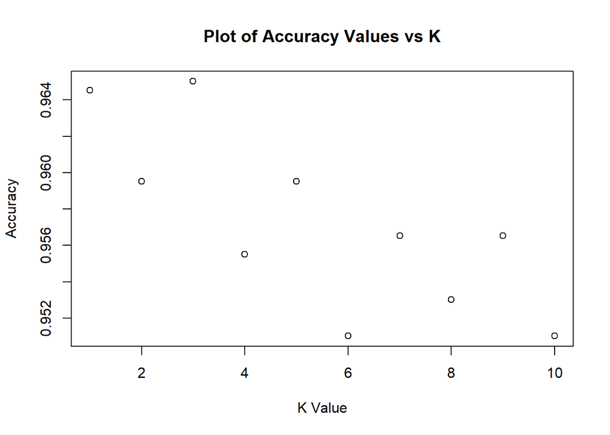

```r
# Rough plot of the accuracies to see the trend in data
plot(x = accuracy.df$k,y = accuracy.df$accuracy, main = "Plot of Accuracy Values vs K", xlab = "K Value", ylab = "Accuracy")
```

```r
# Create the KNN model with K = 1 and only training and test data
knn_model2 <- knn(train = Bank_1_Train_Norm[, -6], test = Bank_1_Test_Norm[, -6],
          cl = Bank_1_Train_Norm[, 6], k = 1, prob = TRUE)
# Confusion Matrix
predicted <- as.factor(knn_model2)
actual <- as.factor(Bank_1_Test_Norm[, 6])
confusionMatrix(predicted, actual, positive = "1")
```

```
## Confusion Matrix and Statistics
##
##           Reference
## Prediction    0    1
##          0 1811   53
##          1   18  119
##
##                Accuracy : 0.9645
##                  95% CI : (0.9555, 0.9722)
##     No Information Rate : 0.914
##     P-Value [Acc > NIR] : < 2.2e-16
##
##                   Kappa : 0.7513
##
##  Mcnemar's Test P-Value : 5.459e-05
##
##             Sensitivity : 0.69186
##             Specificity : 0.99016
##          Pos Pred Value : 0.86861
##          Neg Pred Value : 0.97157
##              Prevalence : 0.08596
##          Detection Rate : 0.05947
##    Detection Prevalence : 0.06847
##       Balanced Accuracy : 0.84101
##
##        'Positive' Class : 1
##
```

3. Confusion matrix of the KNN model using K = 1.

```r
# Run the KNN model on the customer profile with the K = 1 value
knn_model_customer2 <- knn(train = Bank_1_Train_Norm[, -6], test = customer,
          cl = Bank_1_Train_Norm[, 6], k = 3, prob = TRUE)
# Return the value predicted by the model
as.data.frame(knn_model_customer2)
```

```
##   knn_model_customer2
## 1                   0
```

4. The customer is this case is still predicted to not accept the personal loan.

```r
# Set the seed for randomized functions
set.seed(100619)
# Split the data into 50% training data, 30% validation data, and 20% test data
Bank_2_Index <- createDataPartition(Bank_1$Age, p=0.2, list = F)
Bank_2_Test <- Bank_1[Bank_2_Index,]
Bank_2_Remaining <- Bank_1[-Bank_2_Index,]
Bank_2_Index <- createDataPartition(Bank_2_Remaining$Age, p=0.625, list = F)
Bank_2_Train <- Bank_2_Remaining[Bank_2_Index,]
Bank_2_Validation <- Bank_2_Train[-Bank_2_Index,]
```

The newly divided data will now need to be normalized, as we did before.

```r
# Create a copy of the data sets for normalization
Bank_2_Train_Norm <- Bank_2_Train
Bank_2_Test_Norm <- Bank_2_Test
Bank_2_Validation_Norm <- Bank_2_Validation
# Use preProcess function to create a model for centering and scaling the data
Norm_Values <- preProcess(Bank_2_Train[, c(1:5)], method = c("center", "scale"))
# Replace the numeric variables with normalized and centered data
Bank_2_Train_Norm[, c(1:5)] <- predict(Norm_Values, Bank_2_Train[, c(1:5)])
Bank_2_Test_Norm[, c(1:5)] <- predict(Norm_Values, Bank_2_Test[, c(1:5)])
Bank_2_Validation_Norm[, c(1:5)] <- predict(Norm_Values, Bank_2_Validation[, c(1:5)])
```

We will now re-run the KNN model with the newly divided data sets.

5. The confusion matricies for the test data should have lower accuracy results, because it holds data that has not been seen by the model when training it. Therefore, the confusion matrix for training data should be more accurate, because it has already seen the data that it is predicting. Depending on exactly what metric we want to compare, there could be comparisons made about precision, recall, accuracy, specificity, etc.

The first confusion matrix is for the “test” data:

```r
# Create the KNN model with K = 1
knn_model_test <- knn(train = Bank_2_Train_Norm[, -6], test = Bank_2_Test_Norm[, -6],
          cl = Bank_2_Train_Norm[, 6], k = 1, prob = TRUE)
# Confusion Matrix
predicted_test <- as.factor(knn_model_test)
actual_test <- as.factor(Bank_2_Test_Norm[, 6])
confusionMatrix(predicted_test, actual_test, positive = "1")
```

```
## Confusion Matrix and Statistics
##
##           Reference
## Prediction   0   1
##          0 898  25
##          1   6  72
##
##                Accuracy : 0.969
##                  95% CI : (0.9563, 0.9789)
##     No Information Rate : 0.9031
##     P-Value [Acc > NIR] : 4.834e-16
##
##                   Kappa : 0.8061
##
##  Mcnemar's Test P-Value : 0.001225
##
##             Sensitivity : 0.74227
##             Specificity : 0.99336
##          Pos Pred Value : 0.92308
##          Neg Pred Value : 0.97291
##              Prevalence : 0.09690
##          Detection Rate : 0.07193
##    Detection Prevalence : 0.07792
##       Balanced Accuracy : 0.86782
##
##        'Positive' Class : 1
##
```

The second confusion matrix is for the “validation” data:

```r
# Create the KNN model with K = 1
knn_model_validation <- knn(train = Bank_2_Train_Norm[, -6], test = Bank_2_Validation_Norm[, -6],
          cl = Bank_2_Train_Norm[, 6], k = 1, prob = TRUE)
# Confusion Matrix
predicted_validation <- as.factor(knn_model_validation)
actual_validation <- as.factor(Bank_2_Validation_Norm[, 6])
confusionMatrix(predicted_validation, actual_validation, positive = "1")
```

```
## Confusion Matrix and Statistics
##
##           Reference
## Prediction   0   1
##          0 856   0
##          1   0  92
##
##                Accuracy : 1
##                  95% CI : (0.9961, 1)
##     No Information Rate : 0.903
##     P-Value [Acc > NIR] : < 2.2e-16
##
##                   Kappa : 1
##
##  Mcnemar's Test P-Value : NA
##
##             Sensitivity : 1.00000
##             Specificity : 1.00000
##          Pos Pred Value : 1.00000
##          Neg Pred Value : 1.00000
##              Prevalence : 0.09705
##          Detection Rate : 0.09705
##    Detection Prevalence : 0.09705
##       Balanced Accuracy : 1.00000
##
##        'Positive' Class : 1
##
```

The third confusion matrix is for the “train” data:

```r
# Create the KNN model with K = 1
knn_model_train <- knn(train = Bank_2_Train_Norm[, -6], test = Bank_2_Train_Norm[, -6],
          cl = Bank_2_Train_Norm[, 6], k = 1, prob = TRUE)
# Confusion Matrix
predicted_train <- as.factor(knn_model_train)
actual_train <- as.factor(Bank_2_Train_Norm[, 6])
confusionMatrix(predicted_train, actual_train, positive = "1")
```

```
## Confusion Matrix and Statistics
##
##           Reference
## Prediction    0    1
##          0 2250    0
##          1    0  251
##
##                Accuracy : 1
##                  95% CI : (0.9985, 1)
##     No Information Rate : 0.8996
##     P-Value [Acc > NIR] : < 2.2e-16
##
##                   Kappa : 1
##
##  Mcnemar's Test P-Value : NA
##
##             Sensitivity : 1.0000
##             Specificity : 1.0000
##          Pos Pred Value : 1.0000
##          Neg Pred Value : 1.0000
##              Prevalence : 0.1004
##          Detection Rate : 0.1004
##    Detection Prevalence : 0.1004
##       Balanced Accuracy : 1.0000
##
##        'Positive' Class : 1
##
```